# 06_project_rev02_02

Привет Юлия!

Меня зовут Александр Непомнящий и я буду проверять твой проект. Предлагаю общаться на «ты» :))) Но, если это не удобно - мы вполне можем перейти на вы".

Вкратце обо мне: я работаю в сфере информационных технологий, аналитика (анализ) данных - это и мой рабочий функционал и личная, интересная мне область для саморазвития. Используемый стек: python, pandas, графические библиотеки matplotlib/seaborn/plotly. Сфера применения: маркетинговая аналитика в медицинской клинике (Клиника «Кивач», www.kivach.ru, республика Карелия). Если вдруг есть вопрос – что делает аналитик в коммерческой медицине – то вот короткий ответ. Самый главный вопрос, на который мы хотим получить ответ (и который в дальнейшем приведёт к перераспределению рекламного бюджета, плюс напрямую повлияет на разработку и предложению рынку новых лечебных программ) - это КТО ОН, НАШ КЛИЕНТ? Фактически это задача (на нашем внутреннем языке формулируется как построение и анализ «ПОРТРЕТА КЛИЕНТА»). Визуализируем и пытаемся придать смысл половозрастным данным наших клиентов, кто из какого региона и в какие времена года к нам приезжает. Учитываем количество приездов. Учитываем на какую программу этот конкретный клиент приехал в первый раз и как в дальнейшем меняются его предпочтения. Пытаемся построить модель оттока и спрогнозировать, когда клиент уйдёт в отток. Смотрим цифры (суммы трат клиентов на отдельных группах медицинских программ). Анализируем медицинские услуги, которые входят в путёвку, а также что, в каких количествах и на какую сумму клиент покупает дополнительно. Очень вкратце как-то так.

Теперь к сути: основная цель моей проверки - пройти по шагам, по логике твоего решения и обсудить те моменты, которые можно изменить, улучшить, довести до идеала. Такой формат работы двух программистов (аналитиков) ты или уже встречал(а), или встретишь на своей новой работе. Кто-то такой процесс называет "код-ревью", ну а как по мне, так это обмен опытом двух коллег, когда каждый из нас становиться лучше в процессе дискуссии.

Свои мысли, советы, комментарии и вопросы я буду оставлять в текстовых ячейках (markdown) ПОД твоим кодом. Для твоего удобства все эти заметки будут "цветными", как на примерах ниже:

"Зелеными" комментариями я буду отмечать твой элегантный ("красивый") код и/или удачные решения, на которые ты можешь смело опираться в будущих проектах.

**Отлично! 👍**

Отличная находка, элегантный код ...

"Жёлтые" комментарии - это мои размышления, предложения, что-то, что в следующий раз можно сделать по-другому. "Жёлтые" комментарии не требуют твоих правок в проекте и их наличие НИКАК не повлияет на результат моей проверки. Но я искренне верю, что наш двусторонний диалог под "желтым" комментарием - это то, от чего твой проект только выиграет.

**Комментарий 👉**

Здесь я бы предложил использовать .... Мои аргументы в пользу этого ...

"Красные" комментарий будут появляться, когда что-то пойдёт не так: например, код будет выдавать ошибку. Или, когда в проекте не будет ответов на основные вопросы, ради которых весь анализ и выполнялся. "Красные" комментарии необходимо будет исправить, прежде чем я смогу принять проект.

**Необходимо исправить ❌**

В этой ячейке код работает не так как задумано ...

Пожалуйста, не перемещай, не изменяй и не удаляй мои комментарии. Это поможет мне оперативно выполнить повторную проверку твоего проекта.

Давай работать над проектом в диалоге: если ты что-то меняешь в проекте по моим рекомендациям — пиши об этом, лучше всего в новой ячейке, сразу под моим комментарием. Если для своих комментариев ты будешь использовать какой-то заметный цвет, то мне будет легче отследить твои изменения, например так:

**КОММЕНТАРИЙ СТУДЕНТА**  
Текст твоего комментария ...

Ну и наконец информируй меня в том случае, если по твоему проекту подходит дедлайн! В таком случае я приложу усилия, чтобы ты сдал(а) его вовремя; буду оперативно, в приоритете проверять итерации ревью, а также отвечать на твои вопросы, если этого будет требовать ситуация.

**Распространенные типичные недочёты в проектах студентов:**

Неработоспособный код. Проверь проект на работоспособность перед отправкой на проверку. Это важный навык, который тебе пригодится как на собеседовании, при выполнении тестового задания, так и перед совещанием у руководства компании.

Проект не структурирован. В проекте должна быть структура, т.е. названия разделов и подразделов должны быть записаны в ячейках Markdown.

Отсутствие описания, целей проекта, его задач, выводов. В описании должны быть озвучены поставленные задачи, содержание датасета, промежуточные и финальные выводы. Как правило, заказчик читает только финальный вывод, поэтому важно добавить информацию о проведенном исследовании, применить форматирование текста, в общем, сделать красиво, чтобы было понятно, что проведено настоящее исследование и выводу можно верить.

"Длинный код". Код и и комментарии, которые прячутся за правым концом ячейки нужно переносить на новую строку. Твои будущие коллеги не оценят необходимость постоянного скроллинга. Согласно PEP8: https://www.python.org/dev/peps/pep-0008/ длина строки не должна превышать 79 символов.

Твои коллеги ценят и твое и своё время, поэтому "подсвечивай" свои комментарии в ячейках Markdown. Подробнее про синтаксис Markdown, с примерами, можно почитать здесь: https://paulradzkov.com/2014/markdown_cheatsheet/?

# Анализ игровых платформ Xbox и PlayStation

# Описание проекта

К рассмотрению представлен интернет-магазин «Стримчик», который продаёт по всему миру компьютерные игры. Из открытых источников доступны исторические данные до 2016 года о продажах игр, оценки пользователей и экспертов, жанры и платформы (например, Xbox или PlayStation). Необходимо выявить определяющие успешность игры закономерности. Это позволит сделать ставку на потенциально популярный продукт и спланировать рекламные кампании.  
В наборе данных попадается аббревиатура ESRB (Entertainment Software Rating Board) — это ассоциация, определяющая возрастной рейтинг компьютерных игр. ESRB оценивает игровой контент и присваивает ему подходящую возрастную категорию, например, «Для взрослых», «Для детей младшего возраста» или «Для подростков».

# Описание данных

- Name — название игры
- Platform — платформа
- Year_of_Release — год выпуска
- Genre — жанр игры
- NA_sales — продажи в Северной Америке (миллионы проданных копий)
- EU_sales — продажи в Европе (миллионы проданных копий)
- JP_sales — продажи в Японии (миллионы проданных копий)
- Other_sales — продажи в других странах (миллионы проданных копий)
- Critic_Score — оценка критиков (максимум 100)
- User_Score — оценка пользователей (максимум 10)
- Rating — рейтинг от организации ESRB (англ. Entertainment Software Rating Board). Эта ассоциация определяет рейтинг компьютерных игр и присваивает им подходящую возрастную категорию.

Данные за 2016 год могут быть неполными.

# 1. Открытие файл с данными и изучение общей информации

Путь к файлу: /datasets/games.csv.

# 2. Подготовка данных

- Заменить названия столбцов (привести к нижнему регистру);
- Преобразовать данных в нужные типы. Описать, в каких столбцах заменили тип данных и почему;
- Обработать пропусков при необходимости: объяснить, почему заполнили пропуски определённым образом или почему не стали это делать; описать причины, которые могли привести к пропускам;
- Обратить внимание на аббревиатуру 'tbd' в столбце с оценкой пользователей. Отдельно разобрать это значение и описать, как его обработать;
- Посчитать суммарные продажи во всех регионах и записать их в отдельный столбец.

# 3. Провести исследовательский анализ данных

- Посмотреть, сколько игр выпускалось в разные годы. Важны ли данные за все периоды?
- Посмотреть, как менялись продажи по платформам. Выбрать платформы с наибольшими суммарными продажами и построить распределение по годам.
- За какой характерный срок появляются новые и исчезают старые платформы?
- Взять данные за соответствующий актуальный период. Актуальный период определить самостоятельно в результате исследования предыдущих вопросов. Основной фактор — эти данные помогут построить прогноз на 2017 год. Не учитывайте в работе данные за предыдущие годы.
- Какие платформы лидируют по продажам, растут или падают? Выберать несколько потенциально прибыльных платформ.
- Построить график «ящик с усами» по глобальным продажам игр в разбивке по платформам. Описать результат.
- Посмотреть, как влияют на продажи внутри одной популярной платформы отзывы пользователей и критиков.
- Построить диаграмму рассеяния и посчитать корреляцию между отзывами и продажами. Сформулировать выводы.
- Соотнести выводы с продажами игр на других платформах.
- Посмотреть на общее распределение игр по жанрам. Что можно сказать о самых прибыльных жанрах? Выделяются ли жанры с высокими и низкими продажами?

# 4. Составить портрет пользователя каждого региона

Определить для пользователя каждого региона (NA, EU, JP):

- Самые популярные платформы (топ-5). Описать различия в долях продаж.
- Самые популярные жанры (топ-5). Пояснить разницу.
- Влияет ли рейтинг ESRB на продажи в отдельном регионе?

# 5. Проверить гипотезы

- Средние пользовательские рейтинги платформ Xbox One и PC одинаковые;
- Средние пользовательские рейтинги жанров Action (англ. «действие», экшен-игры) и Sports (англ. «спортивные соревнования») разные.

Задать самостоятельно пороговое значение alpha.  
Пояснить:  
Как вы сформулировали нулевую и альтернативную гипотезы;  
Какой критерий применили для проверки гипотез и почему.

# 6. Написать общий вывод

# 1. Открытие файл с данными и изучение общей информации

```python
# вызов библиотеки pandas
import pandas as pd
# импорт библиотеки matplotlib
import matplotlib.pyplot as plt
# импорт библиотеки numpy
import numpy as np
# импорт библиотеки seaborn
import seaborn as sns
# импорт библиотеки scipy
import scipy
from scipy import stats as st
# импорт библиотеки warnings
import warnings
```

```python
# чтение файла
try:
    games = pd.read_csv(r'c:\\Users\\Юки\\AnaliticData\\1_СБОРНЫЙ_ПРОЕКТ\\games.csv') #, sep='\t')
except:
    games = pd.read_csv('https://code.s3.yandex.net/datasets/games.csv')
```

**ОТЛИЧНО! 👍**

Здесь хорошо! При такой загрузке данных и тебе комфортно работать с проектом на домашнем ПК и у меня всё ОК во время проверки проекта в Юпитер Хабе

```python
# вывод на экран датасета
games.sample(5)
```

|  | Name | Platform | Year_of_Release | Genre | NA_sales | EU_sales | JP_sales | Other_sales | Critic_Score | User_Score | Rating |
| --- | --- | --- | --- | --- | --- | --- | --- | --- | --- | --- | --- |
| 9285 | Scene It? Bright Lights! Big Screen! | X360 | 2009.0 | Misc | 0.12 | 0.00 | 0.00 | 0.01 | NaN | NaN | NaN |
| 14983 | Beyblade Burst | 3DS | 2016.0 | Role-Playing | 0.00 | 0.00 | 0.03 | 0.00 | NaN | NaN | NaN |
| 15582 | Crysis: Warhead | PC | 2008.0 | Shooter | 0.00 | 0.02 | 0.00 | 0.00 | 84.0 | 7.9 | M |
| 2655 | UFC Personal Trainer: The Ultimate Fitness System | X360 | 2011.0 | Sports | 0.53 | 0.18 | 0.00 | 0.06 | 70.0 | 6.5 | E |
| 6358 | Magical Vacation | GBA | 2001.0 | Role-Playing | 0.00 | 0.00 | 0.26 | 0.01 | NaN | NaN | NaN |

```python
# просмотр общей информации о датасете
games.info()
```

```
<class 'pandas.core.frame.DataFrame'>
RangeIndex: 16715 entries, 0 to 16714
Data columns (total 11 columns):
 #   Column           Non-Null Count  Dtype
---  ------           --------------  -----
 0   Name             16713 non-null  object
 1   Platform         16715 non-null  object
 2   Year_of_Release  16446 non-null  float64
 3   Genre            16713 non-null  object
 4   NA_sales         16715 non-null  float64
 5   EU_sales         16715 non-null  float64
 6   JP_sales         16715 non-null  float64
 7   Other_sales      16715 non-null  float64
 8   Critic_Score     8137 non-null   float64
 9   User_Score       10014 non-null  object
 10  Rating           9949 non-null   object
dtypes: float64(6), object(5)
memory usage: 1.4+ MB
```

**Комментарий 👉**

Выводить весь датафрейм можно, но как правило я так не делаю (пространство на мониторе конЕчно, особенно когда в нескольких ячейках необходимо последовательно посмотреть, что в датафрейме изменилось). Достаточно "типового" .head() с 5 строками - как подтверждение того, что данные в датафрейм загружены верно. Если же в твоём случае считать, что 5 строк в начале и 5 строк в конце - это как массив из которого будет видно какие проблемы есть с данными (пропуски, аномальные значения), то поверь, для датафрейма с 16+ тысячами записей 10 строк это "капля в море". Проблемы с данными видны не будут. Для анализа мы будем использовать другие инструменты: .info(), .describe() и т.д.

Если же ты выводишь датафрейм "полностью" для того, чтобы размерность датафрейма была на экране, то "красивее" использовать .shape в отдельной ячейке.

**КОММЕНТАРИЙ СТУДЕНТА**

вывод на экран датасета командой **display(games)** совершен умышленно - с целью рассмотения 5 строк в начале и 5 строк в конце - для выявления возможных артефактов.  
!Внесено изменение - с целью "поддержания идеи" и корректного вывода, использован метод sample()

```python
games_isnull_Value = games.isnull().sum().sort_values(ascending = False)
games_isnull_Percent = round(games.isnull().mean().sort_values(ascending = False)*100,2)
games_isnull = pd.concat([games_isnull_Value, games_isnull_Percent], axis=1, keys=['Пропущенные значения', 'Процент'])
games_isnull
```

|  | Пропущенные значения | Процент |
| --- | --- | --- |
| Critic_Score | 8578 | 51.32 |
| Rating | 6766 | 40.48 |
| User_Score | 6701 | 40.09 |
| Year_of_Release | 269 | 1.61 |
| Name | 2 | 0.01 |
| Genre | 2 | 0.01 |
| Platform | 0 | 0.00 |
| NA_sales | 0 | 0.00 |
| EU_sales | 0 | 0.00 |
| JP_sales | 0 | 0.00 |
| Other_sales | 0 | 0.00 |

**ОТЛИЧНО! 👍**

Это хорошо! "Отображение" пропусков в процентах воспринимается проще и нагляднее, чем в абсолютных единицах.

**Вывод:**

- Загруженный датафрейм содержит 16715 наблюдений и 11 признаков;
- 6 признака числовые, остальные 5 - категориальные, однако у некоторых признаков необходимо изменить тип: столбец User_Score содержит числовые данные, а столбец Year_of_Release - информацию о дате;
- в таблице почти нет пропусков данных в данных о названиях платформ, игр, жанров и продажах, небольшое количество пропусков в годах выпуска и достаточно много пропусков в столбцах оценок и рейтинга - возможно, эти пропуски не случайны;
- названия столбцов кажутся правильными, но требуют приведению к нижнему регистру.

**ОТЛИЧНО! 👍**

Спасибо за точный и конкретный вывод по предварительному анализу загруженных данных. Зачастую коллеги ограничиваются исключительно кодом, без слов. Ввиду чего непонятно к каким выводам они пришли и что собираются делать дальше.

# 2. Подготовка данных

**Переименование столбцов, перевод названий в нижний регистр**

```python
games.columns = games.columns.str.lower()
games.head()
```

|  | name | platform | year_of_release | genre | na_sales | eu_sales | jp_sales | other_sales | critic_score | user_score | rating |
| --- | --- | --- | --- | --- | --- | --- | --- | --- | --- | --- | --- |
| 0 | Wii Sports | Wii | 2006.0 | Sports | 41.36 | 28.96 | 3.77 | 8.45 | 76.0 | 8 | E |
| 1 | Super Mario Bros. | NES | 1985.0 | Platform | 29.08 | 3.58 | 6.81 | 0.77 | NaN | NaN | NaN |
| 2 | Mario Kart Wii | Wii | 2008.0 | Racing | 15.68 | 12.76 | 3.79 | 3.29 | 82.0 | 8.3 | E |
| 3 | Wii Sports Resort | Wii | 2009.0 | Sports | 15.61 | 10.93 | 3.28 | 2.95 | 80.0 | 8 | E |
| 4 | Pokemon Red/Pokemon Blue | GB | 1996.0 | Role-Playing | 11.27 | 8.89 | 10.22 | 1.00 | NaN | NaN | NaN |

**Обработаем пропуски**

```python
# посмотрим на строки с пропущенными значениями в именах игр
games[games['name'].isna()]
```

|  | name | platform | year_of_release | genre | na_sales | eu_sales | jp_sales | other_sales | critic_score | user_score | rating |
| --- | --- | --- | --- | --- | --- | --- | --- | --- | --- | --- | --- |
| 659 | NaN | GEN | 1993.0 | NaN | 1.78 | 0.53 | 0.00 | 0.08 | NaN | NaN | NaN |
| 14244 | NaN | GEN | 1993.0 | NaN | 0.00 | 0.00 | 0.03 | 0.00 | NaN | NaN | NaN |

```python
print('Количество строк до удаления: ',games.shape[0])
```

```
Количество строк до удаления:  16715
```

Пропуски в столбце **name** соответствуют отсутствующим значениям столбца **genre** - скорее всего связано с техническим сбоем, ввиду малого количества - удалим данные строки.

```python
games = games.dropna(subset=['name'])
```

```python
print('Количество строк после удаления: ',games.shape[0])
```

```
Количество строк после удаления:  16713
```

**ОТЛИЧНО! 👍**

Молодец! Правильный вывод! И порядок действий правильный - вначале посмотреть на данные, а уже потом принимать решение.

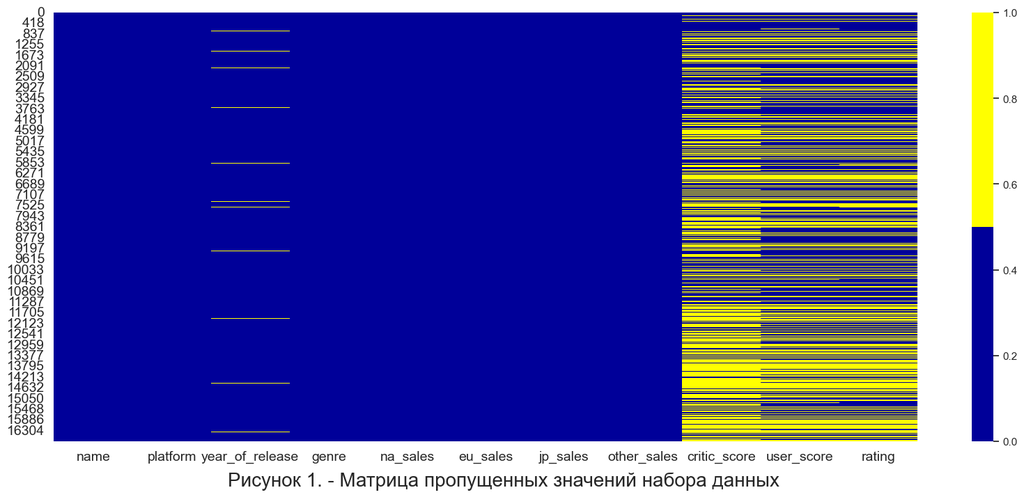

```python
# c помощью библиотеки seaborn построим тепловую карту для визуализации данных
sns.set(rc={'figure.figsize':(20,8)})
sns.heatmap(games.isnull(), cmap=sns.color_palette(['#000099', '#ffff00']))
# Оформление графика
plt.xticks(fontsize=14)
plt.yticks(fontsize=14)
plt.figtext(0.25, 0.03, "Рисунок 1. - Матрица пропущенных значений набора данных", fontsize=20)
plt.show()
```

Исходя из визуализации можем отметить:

- пропуски значений в столбце **дата выпуска** единичны (1.6%), удаляя строки с пропущенными значениями по данному признаку - не потеряем ценной информации;
- основная часть пропущенных данных содержится в столбцах оценок и рейтинга;
- пропуски соответствуют отсутствующим значениям почти для всех строк в столбцах оценок и рейтинга - удалять строки с отсутствующими в них значениями не будем.

Видимо выборка содержит неоцененные по определенным причинам игры, в связи с чем пропуски не случайны.

**ОТЛИЧНО! 👍**

Отлично, проведена работа по анализу пропусков, в принципе высказан ряд корректных предположений на тему природы пропусков в оценках игр и пропусков в рейтингах.

```python
games[games['year_of_release'].isnull()]#.sort_values(by='na_sales', ascending=False)
```

|  | name | platform | year_of_release | genre | na_sales | eu_sales | jp_sales | other_sales | critic_score | user_score | rating |
| --- | --- | --- | --- | --- | --- | --- | --- | --- | --- | --- | --- |
| 183 | Madden NFL 2004 | PS2 | NaN | Sports | 4.26 | 0.26 | 0.01 | 0.71 | 94.0 | 8.5 | E |
| 377 | FIFA Soccer 2004 | PS2 | NaN | Sports | 0.59 | 2.36 | 0.04 | 0.51 | 84.0 | 6.4 | E |
| 456 | LEGO Batman: The Videogame | Wii | NaN | Action | 1.80 | 0.97 | 0.00 | 0.29 | 74.0 | 7.9 | E10+ |
| 475 | wwe Smackdown vs. Raw 2006 | PS2 | NaN | Fighting | 1.57 | 1.02 | 0.00 | 0.41 | NaN | NaN | NaN |
| 609 | Space Invaders | 2600 | NaN | Shooter | 2.36 | 0.14 | 0.00 | 0.03 | NaN | NaN | NaN |
| ... | ... | ... | ... | ... | ... | ... | ... | ... | ... | ... | ... |
| 16373 | PDC World Championship Darts 2008 | PSP | NaN | Sports | 0.01 | 0.00 | 0.00 | 0.00 | 43.0 | tbd | E10+ |
| 16405 | Freaky Flyers | GC | NaN | Racing | 0.01 | 0.00 | 0.00 | 0.00 | 69.0 | 6.5 | T |
| 16448 | Inversion | PC | NaN | Shooter | 0.01 | 0.00 | 0.00 | 0.00 | 59.0 | 6.7 | M |
| 16458 | Hakuouki: Shinsengumi Kitan | PS3 | NaN | Adventure | 0.01 | 0.00 | 0.00 | 0.00 | NaN | NaN | NaN |
| 16522 | Virtua Quest | GC | NaN | Role-Playing | 0.01 | 0.00 | 0.00 | 0.00 | 55.0 | 5.5 | T |

269 rows × 11 columns

```python
#сохраним строки с пропущенными значениями в датафрейм games_isnull,
#к которому всегда сможем обратиться в случае необходимости
games_isnull = games[games['year_of_release'].isnull()]
games_isnull.head()
```

|  | name | platform | year_of_release | genre | na_sales | eu_sales | jp_sales | other_sales | critic_score | user_score | rating |
| --- | --- | --- | --- | --- | --- | --- | --- | --- | --- | --- | --- |
| 183 | Madden NFL 2004 | PS2 | NaN | Sports | 4.26 | 0.26 | 0.01 | 0.71 | 94.0 | 8.5 | E |
| 377 | FIFA Soccer 2004 | PS2 | NaN | Sports | 0.59 | 2.36 | 0.04 | 0.51 | 84.0 | 6.4 | E |
| 456 | LEGO Batman: The Videogame | Wii | NaN | Action | 1.80 | 0.97 | 0.00 | 0.29 | 74.0 | 7.9 | E10+ |
| 475 | wwe Smackdown vs. Raw 2006 | PS2 | NaN | Fighting | 1.57 | 1.02 | 0.00 | 0.41 | NaN | NaN | NaN |
| 609 | Space Invaders | 2600 | NaN | Shooter | 2.36 | 0.14 | 0.00 | 0.03 | NaN | NaN | NaN |

```python
print('Количество строк до удаления: ',games.shape[0])
```

```
Количество строк до удаления:  16713
```

```python
# удалим строки с пропущенными значениями по столбцу year_of_release
games = games.dropna(subset=['year_of_release']).reset_index(drop=True)
```

```python
print('Количество строк после удаления: ',games.shape[0])
```

```
Количество строк после удаления:  16444
```

**Комментарий 👉**

Перед удалением, операцией по сути деструктивной, я бы рекомендовал посмотреть на записи с пропусками в соответствующих колонках, по отдельности (может эти записи по 100 млн. продаж принесли). 269 записей с пропусками в годе выпуска вроде немного, но ты учитывай тот факт, что все задачи в это проекте так или иначе связаны как раз с годом выпуска ... "В жизни" лишний взгляд на данные лишним не бывает.

**Комментарий 👉**

И ещё небольшой, но жизненный совет: **перед** и **сразу после** удаления строк (и для столбцов тоже будет верно) примени метод .shape к датафрейму. В этом случае наглядно будет видно сколько строк/столбцов было удалено. В некоторых ситуациях может быть ошибка в коде из-за которой удаляется больше чем ожидалось. Но этот способ поможет тебе такую проблему сразу обнаружить.

**Комментарий 👉**

(Немного рассуждений): да, всего 2 записи (из 16 тысяч) с пропусками в жанрах и названиях (плюс в этих же записях нет ни оценок пользователей, ни оценок критиков, ни рейтингов) и 269 записей (менее 2% из 16+ тысяч) с пропусками в годах выпуска. Казалось бы, надо удалять даже не раздумывая … но единого сценария нет на самом деле. С одной стороны - да, говорят, что "данных много не бывает", удалять записи из-за пропусков, когда датасет измеряется всего лишь сотнями-тысячами записей ой как не хочется.

С другой стороны, если запись не спасти, если в ней несколько полей не заполнено или не заполнены ключевые поля, и ты чувствуешь, что заполнение их медианами/средними приведёт к смещению статистик - надо удалять. Да, можно поставить "заглушку", но тогда надо отдавать отчёт, что во всем последующем коде про эту "заглушку" помнить придётся. Т.е. перед построением всех графиков, гистограмм заглушку надо будет удалить. Перед расчетом корреляций - заглушку надо будет удалить. Перед проверкой гипотез заглушку надо будет удалить.

Я бы так определил способ решения такой задачи: если записи с пропусками в ключевых для моего анализа полях составляют 1-3-5-до 10% строк, то я бы их из оригинального датафрейма вырезал (но сохранил бы в некий df, к которому при необходимости мог бы обратиться).

А вообще, в таких случаях, когда нужно решить - заполнять пропуски или удалять строки с ними из df - всегда ищи эксперта в предметной области и советуйся с ним. Как правило это человек из бизнеса, который значит суть бизнес-процесса и вот именно он даст тебе точный и аргументированный совет - что в данной, конкретной задаче делать с "битыми" полями в строках датафрейма.

**КОММЕНТАРИЙ СТУДЕНТА**

Рекомедации учтены:

- перед и после удаления применен метод .shape - для контроля количества удаленных строк;
- сохранены записи с пропусками в столбце **year_of_release** в датафрейме games_isnull

```python
# просмотр уникальных значений столбца пользовательских оценок
print(games['user_score'].unique())
```

```
['8' nan '8.3' '8.5' '6.6' '8.4' '8.6' '7.7' '6.3' '7.4' '8.2' '9' '7.9'
 '8.1' '8.7' '7.1' '3.4' '5.3' '4.8' '3.2' '8.9' '6.4' '7.8' '7.5' '2.6'
 '7.2' '9.2' '7' '7.3' '4.3' '7.6' '5.7' '5' '9.1' '6.5' 'tbd' '8.8' '6.9'
 '9.4' '6.8' '6.1' '6.7' '5.4' '4' '4.9' '4.5' '9.3' '6.2' '4.2' '6' '3.7'
 '4.1' '5.8' '5.6' '5.5' '4.4' '4.6' '5.9' '3.9' '3.1' '2.9' '5.2' '3.3'
 '4.7' '5.1' '3.5' '2.5' '1.9' '3' '2.7' '2.2' '2' '9.5' '2.1' '3.6' '2.8'
 '1.8' '3.8' '0' '1.6' '9.6' '2.4' '1.7' '1.1' '0.3' '1.5' '0.7' '1.2'
 '2.3' '0.5' '1.3' '0.2' '0.6' '1.4' '0.9' '1' '9.7']
```

```python
# просмотр уникальных значений столбца оценок критиков
print(games['critic_score'].unique())
```

```
[76. nan 82. 80. 89. 58. 87. 91. 61. 97. 95. 77. 88. 83. 94. 93. 85. 86.
 98. 96. 90. 84. 73. 74. 78. 92. 71. 72. 68. 62. 49. 67. 81. 66. 56. 79.
 70. 59. 64. 75. 60. 63. 69. 50. 25. 42. 44. 55. 48. 57. 29. 47. 65. 54.
 20. 53. 37. 38. 33. 52. 30. 32. 43. 45. 51. 40. 46. 39. 34. 41. 36. 31.
 27. 35. 26. 19. 28. 23. 24. 21. 17. 13.]
```

```python
# просмотр уникальных значений столбца рейтинга
print(games['rating'].unique())
```

```
['E' nan 'M' 'T' 'E10+' 'K-A' 'AO' 'EC' 'RP']
```

```python
# осуществим замену пропущенных значений в столбцах critic_score, user_score,rating на пустые значения:
games['critic_score']=games['critic_score'].fillna(150)
games['user_score']=games['user_score'].fillna(150)
games['rating']=games['rating'].fillna('')
```

**ОТЛИЧНО! 👍**

Отлично, принято правильное решение! «Заглушка» (пусть и такая странная )))) для NaN значений в столбце ‘rating’ – это верное решение в этом проекте. Далее, когда ты будешь анализировать особенности регионов в зависимости от рейтинга ESRB, то увидишь, что если бы они остались NaN, то на графиках их не было бы видно, также такие игры "выпали" бы из анализа и выводов, а это красная ошибка в этом проекте.

```python
games.isnull().sum()
```

```
name               0
platform           0
year_of_release    0
genre              0
na_sales           0
eu_sales           0
jp_sales           0
other_sales        0
critic_score       0
user_score         0
rating             0
dtype: int64
```

После проведенных операций выборка не содержит пропуски.

**Преобразуем данных в нужные типы:**

```python
games['year_of_release'] = games['year_of_release'].astype('int')
games.head()
```

|  | name | platform | year_of_release | genre | na_sales | eu_sales | jp_sales | other_sales | critic_score | user_score | rating |
| --- | --- | --- | --- | --- | --- | --- | --- | --- | --- | --- | --- |
| 0 | Wii Sports | Wii | 2006 | Sports | 41.36 | 28.96 | 3.77 | 8.45 | 76.0 | 8 | E |
| 1 | Super Mario Bros. | NES | 1985 | Platform | 29.08 | 3.58 | 6.81 | 0.77 | 150.0 | 150 |  |
| 2 | Mario Kart Wii | Wii | 2008 | Racing | 15.68 | 12.76 | 3.79 | 3.29 | 82.0 | 8.3 | E |
| 3 | Wii Sports Resort | Wii | 2009 | Sports | 15.61 | 10.93 | 3.28 | 2.95 | 80.0 | 8 | E |
| 4 | Pokemon Red/Pokemon Blue | GB | 1996 | Role-Playing | 11.27 | 8.89 | 10.22 | 1.00 | 150.0 | 150 |  |

```python
# преобразуем значения столбца "год выпуска" в тип datetime
games['year_of_release']=pd.to_datetime(games['year_of_release'], format='%Y').dt.year
games.head()
```

|  | name | platform | year_of_release | genre | na_sales | eu_sales | jp_sales | other_sales | critic_score | user_score | rating |
| --- | --- | --- | --- | --- | --- | --- | --- | --- | --- | --- | --- |
| 0 | Wii Sports | Wii | 2006 | Sports | 41.36 | 28.96 | 3.77 | 8.45 | 76.0 | 8 | E |
| 1 | Super Mario Bros. | NES | 1985 | Platform | 29.08 | 3.58 | 6.81 | 0.77 | 150.0 | 150 |  |
| 2 | Mario Kart Wii | Wii | 2008 | Racing | 15.68 | 12.76 | 3.79 | 3.29 | 82.0 | 8.3 | E |
| 3 | Wii Sports Resort | Wii | 2009 | Sports | 15.61 | 10.93 | 3.28 | 2.95 | 80.0 | 8 | E |
| 4 | Pokemon Red/Pokemon Blue | GB | 1996 | Role-Playing | 11.27 | 8.89 | 10.22 | 1.00 | 150.0 | 150 |  |

```python
# рассмотрим содержание столбца user_score
games['user_score'].unique()
```

```
array(['8', 150, '8.3', '8.5', '6.6', '8.4', '8.6', '7.7', '6.3', '7.4',
       '8.2', '9', '7.9', '8.1', '8.7', '7.1', '3.4', '5.3', '4.8', '3.2',
       '8.9', '6.4', '7.8', '7.5', '2.6', '7.2', '9.2', '7', '7.3', '4.3',
       '7.6', '5.7', '5', '9.1', '6.5', 'tbd', '8.8', '6.9', '9.4', '6.8',
       '6.1', '6.7', '5.4', '4', '4.9', '4.5', '9.3', '6.2', '4.2', '6',
       '3.7', '4.1', '5.8', '5.6', '5.5', '4.4', '4.6', '5.9', '3.9',
       '3.1', '2.9', '5.2', '3.3', '4.7', '5.1', '3.5', '2.5', '1.9', '3',
       '2.7', '2.2', '2', '9.5', '2.1', '3.6', '2.8', '1.8', '3.8', '0',
       '1.6', '9.6', '2.4', '1.7', '1.1', '0.3', '1.5', '0.7', '1.2',
       '2.3', '0.5', '1.3', '0.2', '0.6', '1.4', '0.9', '1', '9.7'],
      dtype=object)
```

**tbd** - аббревиатура расшифровывается очень просто - To Be Determined, то есть "Будет определено". Таким образом строки, содержащие аббревиатуру tbd фактически имеют нулевые/пропущеныые значания. Выполним преобразование признака **user_score** в тип float, при этом зададим условие преобразования некорректного значения в NAN, а далее заменим пропуски на пустые значения.

**ОТЛИЧНО! 👍**

То, что ты tbd меняешь на NaN - это правильно. По сути это и есть пропуски (строки с играми, для которых оценка не проставлена, пропущена по каким-то причинам).

```python
games[games['user_score']=='tbd'].head()
```

|  | name | platform | year_of_release | genre | na_sales | eu_sales | jp_sales | other_sales | critic_score | user_score | rating |
| --- | --- | --- | --- | --- | --- | --- | --- | --- | --- | --- | --- |
| 119 | Zumba Fitness | Wii | 2010 | Sports | 3.45 | 2.59 | 0.0 | 0.66 | 150.0 | tbd | E |
| 300 | Namco Museum: 50th Anniversary | PS2 | 2005 | Misc | 2.08 | 1.35 | 0.0 | 0.54 | 61.0 | tbd | E10+ |
| 516 | Zumba Fitness 2 | Wii | 2011 | Sports | 1.51 | 1.03 | 0.0 | 0.27 | 150.0 | tbd | T |
| 639 | uDraw Studio | Wii | 2010 | Misc | 1.65 | 0.57 | 0.0 | 0.20 | 71.0 | tbd | E |
| 709 | Just Dance Kids | Wii | 2010 | Misc | 1.52 | 0.54 | 0.0 | 0.18 | 150.0 | tbd | E |

```python
games['user_score']=pd.to_numeric(games['user_score'], errors='coerce')
games['user_score']=games['user_score'].fillna(150)
```

```python
games.info()
```

```
<class 'pandas.core.frame.DataFrame'>
RangeIndex: 16444 entries, 0 to 16443
Data columns (total 11 columns):
 #   Column           Non-Null Count  Dtype
---  ------           --------------  -----
 0   name             16444 non-null  object
 1   platform         16444 non-null  object
 2   year_of_release  16444 non-null  int64
 3   genre            16444 non-null  object
 4   na_sales         16444 non-null  float64
 5   eu_sales         16444 non-null  float64
 6   jp_sales         16444 non-null  float64
 7   other_sales      16444 non-null  float64
 8   critic_score     16444 non-null  float64
 9   user_score       16444 non-null  float64
 10  rating           16444 non-null  object
dtypes: float64(6), int64(1), object(4)
memory usage: 1.4+ MB
```

**ОТЛИЧНО! 👍**

```python
# проверим наличие дубликатов
games[games.duplicated()]
```

|  | name | platform | year_of_release | genre | na_sales | eu_sales | jp_sales | other_sales | critic_score | user_score | rating |
| --- | --- | --- | --- | --- | --- | --- | --- | --- | --- | --- | --- |

```python
# проверим наличие в выборке дубликатов по признакам name и platform:
games[games.duplicated(subset=['name','platform'], keep=False)].sort_values(by='name')
#games[games[['name','platform']].duplicated(keep=False)].sort_values(by='name')
```

|  | name | platform | year_of_release | genre | na_sales | eu_sales | jp_sales | other_sales | critic_score | user_score | rating |
| --- | --- | --- | --- | --- | --- | --- | --- | --- | --- | --- | --- |
| 600 | Madden NFL 13 | PS3 | 2012 | Sports | 2.11 | 0.22 | 0.00 | 0.23 | 83.0 | 5.5 | E |
| 15969 | Madden NFL 13 | PS3 | 2012 | Sports | 0.00 | 0.01 | 0.00 | 0.00 | 83.0 | 5.5 | E |
| 1177 | Need for Speed: Most Wanted | X360 | 2012 | Racing | 0.62 | 0.78 | 0.01 | 0.15 | 83.0 | 8.5 | T |
| 1574 | Need for Speed: Most Wanted | X360 | 2005 | Racing | 1.00 | 0.13 | 0.02 | 0.10 | 83.0 | 8.5 | T |
| 5883 | Need for Speed: Most Wanted | PC | 2005 | Racing | 0.02 | 0.23 | 0.00 | 0.04 | 82.0 | 8.5 | T |
| 11534 | Need for Speed: Most Wanted | PC | 2012 | Racing | 0.00 | 0.06 | 0.00 | 0.02 | 82.0 | 8.5 | T |

Среди пары признаков "название игры - платформа" выявлены 3 пары дубликатов, две из которых не являются дублями так как имеют отличие по году выпуска, то есть являются обновлениями, выпущенных ранее игр. Игра "Madden NFL 13" действительно задублирована в датафрейме - сложим продажи по данным строкам и удалим дубликат:

```python
# проверим наличие в выборке дубликатов по признакам name и platform, year_of_release, genre:
games[games.duplicated(subset=['name','platform','year_of_release', 'genre'], keep=False)].sort_values(by='name')
```

|  | name | platform | year_of_release | genre | na_sales | eu_sales | jp_sales | other_sales | critic_score | user_score | rating |
| --- | --- | --- | --- | --- | --- | --- | --- | --- | --- | --- | --- |
| 600 | Madden NFL 13 | PS3 | 2012 | Sports | 2.11 | 0.22 | 0.0 | 0.23 | 83.0 | 5.5 | E |
| 15969 | Madden NFL 13 | PS3 | 2012 | Sports | 0.00 | 0.01 | 0.0 | 0.00 | 83.0 | 5.5 | E |

```python
#games.loc[600, 'eu_sales':'other_sales'] = games.loc[[600,15969], 'eu_sales':'other_sales'].sum(axis=0)
#games.iloc[[600]]

rows = games.duplicated(subset=['name','platform','year_of_release', 'genre'], keep=False)

games.loc[rows, 'na_sales'] = games.loc[rows, 'na_sales'].sum()
games.loc[rows, 'eu_sales'] = games.loc[rows, 'eu_sales'].sum()
games.loc[rows, 'jp_sales'] = games.loc[rows, 'jp_sales'].sum()
games.loc[rows, 'other_sales'] = games.loc[rows, 'other_sales'].sum()

games[games.duplicated(subset=['name','platform','year_of_release', 'genre'], keep=False)]
```

|  | name | platform | year_of_release | genre | na_sales | eu_sales | jp_sales | other_sales | critic_score | user_score | rating |
| --- | --- | --- | --- | --- | --- | --- | --- | --- | --- | --- | --- |
| 600 | Madden NFL 13 | PS3 | 2012 | Sports | 2.11 | 0.23 | 0.0 | 0.23 | 83.0 | 5.5 | E |
| 15969 | Madden NFL 13 | PS3 | 2012 | Sports | 2.11 | 0.23 | 0.0 | 0.23 | 83.0 | 5.5 | E |

```python
print('Количество строк до удаления',games.shape[0])
```

```
Количество строк до удаления 16444
```

```python
games.drop_duplicates(subset=['name','platform','year_of_release', 'genre'], inplace = True)
games.reset_index(drop=True)
```

|  | name | platform | year_of_release | genre | na_sales | eu_sales | jp_sales | other_sales | critic_score | user_score | rating |
| --- | --- | --- | --- | --- | --- | --- | --- | --- | --- | --- | --- |
| 0 | Wii Sports | Wii | 2006 | Sports | 41.36 | 28.96 | 3.77 | 8.45 | 76.0 | 8.0 | E |
| 1 | Super Mario Bros. | NES | 1985 | Platform | 29.08 | 3.58 | 6.81 | 0.77 | 150.0 | 150.0 |  |
| 2 | Mario Kart Wii | Wii | 2008 | Racing | 15.68 | 12.76 | 3.79 | 3.29 | 82.0 | 8.3 | E |
| 3 | Wii Sports Resort | Wii | 2009 | Sports | 15.61 | 10.93 | 3.28 | 2.95 | 80.0 | 8.0 | E |
| 4 | Pokemon Red/Pokemon Blue | GB | 1996 | Role-Playing | 11.27 | 8.89 | 10.22 | 1.00 | 150.0 | 150.0 |  |
| ... | ... | ... | ... | ... | ... | ... | ... | ... | ... | ... | ... |
| 16438 | Samurai Warriors: Sanada Maru | PS3 | 2016 | Action | 0.00 | 0.00 | 0.01 | 0.00 | 150.0 | 150.0 |  |
| 16439 | LMA Manager 2007 | X360 | 2006 | Sports | 0.00 | 0.01 | 0.00 | 0.00 | 150.0 | 150.0 |  |
| 16440 | Haitaka no Psychedelica | PSV | 2016 | Adventure | 0.00 | 0.00 | 0.01 | 0.00 | 150.0 | 150.0 |  |
| 16441 | Spirits & Spells | GBA | 2003 | Platform | 0.01 | 0.00 | 0.00 | 0.00 | 150.0 | 150.0 |  |
| 16442 | Winning Post 8 2016 | PSV | 2016 | Simulation | 0.00 | 0.00 | 0.01 | 0.00 | 150.0 | 150.0 |  |

16443 rows × 11 columns

```python
print('Количество строк после удаления',games.shape[0])
```

```
Количество строк после удаления 16443
```

```python
# повторно проверим наличие в выборке дубликатов по признакам name и platform, year_of_release, genre:
games[games.duplicated(subset=['name','platform','year_of_release', 'genre'], keep=False)].sort_values(by='name')
```

|  | name | platform | year_of_release | genre | na_sales | eu_sales | jp_sales | other_sales | critic_score | user_score | rating |
| --- | --- | --- | --- | --- | --- | --- | --- | --- | --- | --- | --- |

**Предложение 👉**

**games[games.duplicated()]** не означает, что в данных нет дубликатов (записей).

В реальных рабочих датасетах скорее всего не будет полных дубликатов, но вот неявные наверняка будут встречаться, соответственно с ними надо будет уметь работать. Попробуй найти неявные дубликаты (нужно использовать параметр **subset**). Ну а в нашем учебном проекте пробуй найти дубликаты для пары "Имя - Игровая консоль".

Как их планируешь и планируешь ли обрабатывать?

**КОММЕНТАРИЙ СТУДЕНТА**

поиск неявных дубликов среди пары признаков "название игры - платформа" позволил выявить пару дублирующих строк, в результете было принято решение об объединение продаж и удаление дубликата: произведенное объединение строк не автоматизировано, т.е. при большом кол-ве дубликатов применить не удасться, в связи с чем - необходимо - прошу подсказать как можно усовершенствовать подход

**Посчитаем суммарные продажи во всех регионах и запишем их в отдельный столбец**

```python
#games['total_sales']=games[['na_sales','eu_sales','jp_sales','other_sales']].sum(axis=1)
games['total_sales'] = games.loc[: , 'na_sales':'other_sales'].sum(axis=1)
#games['total_sales']=games['na_sales']+games['eu_sales']+games['jp_sales']+games['other_sales']

display(games)
```

|  | name | platform | year_of_release | genre | na_sales | eu_sales | jp_sales | other_sales | critic_score | user_score | rating | total_sales |
| --- | --- | --- | --- | --- | --- | --- | --- | --- | --- | --- | --- | --- |
| 0 | Wii Sports | Wii | 2006 | Sports | 41.36 | 28.96 | 3.77 | 8.45 | 76.0 | 8.0 | E | 82.54 |
| 1 | Super Mario Bros. | NES | 1985 | Platform | 29.08 | 3.58 | 6.81 | 0.77 | 150.0 | 150.0 |  | 40.24 |
| 2 | Mario Kart Wii | Wii | 2008 | Racing | 15.68 | 12.76 | 3.79 | 3.29 | 82.0 | 8.3 | E | 35.52 |
| 3 | Wii Sports Resort | Wii | 2009 | Sports | 15.61 | 10.93 | 3.28 | 2.95 | 80.0 | 8.0 | E | 32.77 |
| 4 | Pokemon Red/Pokemon Blue | GB | 1996 | Role-Playing | 11.27 | 8.89 | 10.22 | 1.00 | 150.0 | 150.0 |  | 31.38 |
| ... | ... | ... | ... | ... | ... | ... | ... | ... | ... | ... | ... | ... |
| 16439 | Samurai Warriors: Sanada Maru | PS3 | 2016 | Action | 0.00 | 0.00 | 0.01 | 0.00 | 150.0 | 150.0 |  | 0.01 |
| 16440 | LMA Manager 2007 | X360 | 2006 | Sports | 0.00 | 0.01 | 0.00 | 0.00 | 150.0 | 150.0 |  | 0.01 |
| 16441 | Haitaka no Psychedelica | PSV | 2016 | Adventure | 0.00 | 0.00 | 0.01 | 0.00 | 150.0 | 150.0 |  | 0.01 |
| 16442 | Spirits & Spells | GBA | 2003 | Platform | 0.01 | 0.00 | 0.00 | 0.00 | 150.0 | 150.0 |  | 0.01 |
| 16443 | Winning Post 8 2016 | PSV | 2016 | Simulation | 0.00 | 0.00 | 0.01 | 0.00 | 150.0 | 150.0 |  | 0.01 |

16443 rows × 12 columns

**ОТЛИЧНО! 👍**

Здесь отлично более чем отлично ))) Не все это знают (обычно для "сложения" столбцов коллеги знаком ""+" оперируют).

```python
games.info()
```

```
<class 'pandas.core.frame.DataFrame'>
Int64Index: 16443 entries, 0 to 16443
Data columns (total 12 columns):
 #   Column           Non-Null Count  Dtype
---  ------           --------------  -----
 0   name             16443 non-null  object
 1   platform         16443 non-null  object
 2   year_of_release  16443 non-null  int64
 3   genre            16443 non-null  object
 4   na_sales         16443 non-null  float64
 5   eu_sales         16443 non-null  float64
 6   jp_sales         16443 non-null  float64
 7   other_sales      16443 non-null  float64
 8   critic_score     16443 non-null  float64
 9   user_score       16443 non-null  float64
 10  rating           16443 non-null  object
 11  total_sales      16443 non-null  float64
dtypes: float64(7), int64(1), object(4)
memory usage: 1.6+ MB
```

**Вывод:**

1. все пропуски обработаны - удалены строки с пропущенными значениями в столбцах **name** и **genre** (2 строки), а также в столбце **year_of_release** (269 строк - 1.6 % датасета).

Удаление строк с пропущенными значениями в столбцах рейтинга и оценок пользователей и критиков не было выполнено, т.к. данные пропущенны не случайно - при обработке зависимостей в вышеназванных столбцах данный факт будет учтен. 2. Названия стобцов переведены в нижний регистр. 3. Изменен тип данных в столбецах **User_Score** и **Year_of_Release**. 4. Заменили значение **tbd** в столбце **user_score** на nan, затем применили «заглушку» для дальнейшего корректного исследования. 5. Посчитали суммарные продажи во всех регионах и записали их в столбец **total_sales**

**ОТЛИЧНО! 👍**

Данные загружены, отлично.

Хорошо, что применяешь метод .head()/.sample() таким образом в память не будет загружен весь датасет, объем которого может быть огромным.

Методы .info, .describe, .value_counts(), .unique() как правило часто встречаются и обязательны к применению в задачах по исследованию данных, ведь с их помощью можно получить первые инсайты.

Итак, мы провели предварительный анализ данных, проверили данные на наличие пропусков и затем обработали их (аргументированно заполнили / удалили / оставили как есть). Теперь можно приступать собственно к анализу данных и ответам на вопросы проекта.

# 3. Исследовательский анализ данных

1. Посмотрим, сколько игр выпускалось в разные годы.

```python
#Подсчет количества выпускаемых игр в разные годы
games.groupby('year_of_release')['name'].count()
```

```
year_of_release
1980       9
1981      46
1982      36
1983      17
1984      14
1985      14
1986      21
1987      16
1988      15
1989      17
1990      16
1991      41
1992      43
1993      60
```

[output cut: 24 more lines]

**Комментарий 👉**

Агрегация по count() покажет нам число игр, выпущенных на всех платформах, в разрезе лет. Т.е. если одна и та же игра (name) вышла в некоем году на одной платформе, агрегат == 1. Если на 2-х платформах, агрегат == 2, ну и так далее. У меня вопрос к тебе – что в твоем случае, в написанном тобой коде мы считаем выпуском игры (в этом, некоем году)?

Возможно, чтобы получить истинное количество «игр по годам» нам следует поискать дубликаты (используя subset по (Годам - Названиям игр) и затем исключить из полного датафрейма все дубли за исключением одной, «первой», строки? Как ты считаешь?

**КОММЕНТАРИЙ СТУДЕНТА**

целью данного кода является представление численного количества игр по года в не зависимости от платформ (дубликаты были отработаны в предыдущем разделе), ниже представлена соответствующая визуализация

Количество выпускаемых игр с 1980 (9 игр) по 2008 (1427 игр) увеличивалось, с 2009 (1426 игр) - пошло на спад, в 2016 количнство выпускаемых игр составило 502 штуки.

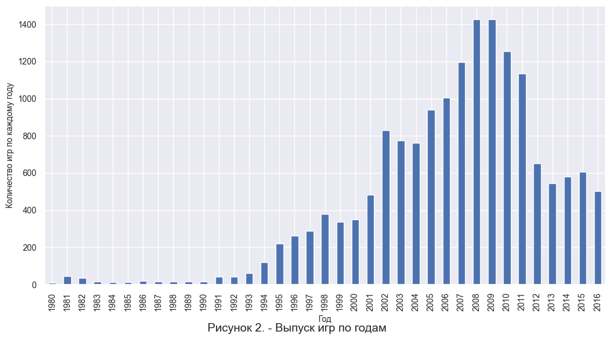

```python
games.groupby('year_of_release').name.count().plot(kind='bar',figsize=(12,6))
plt.xlabel("Год", fontsize=10)
plt.ylabel('Количество игр по каждому году', fontsize=10)
plt.xticks(fontsize=10)
plt.yticks(fontsize=10)
plt.figtext(0.35, -0.02, "Рисунок 2. - Выпуск игр по годам", fontsize=14)
plt.show()
```

**Вывод:** Диаграмма показывает, что начиная с 1980 г. ростет выпуск игр, максимальный значения по количеству достиглись в 2008-2099 гг (более 1400 игр в год), однако начиая с 2010 г. наблюдается спад в выпуске игр - это можно объяснить популярность игр в мобильных телефонах.

**ОТЛИЧНО! 👍**

Просто супер: график подписан, оси подписаны. Не часто на самом деле такой скрупулёзный подход к оформлению встречается. Молодец! Также, здорово, что есть объяснение поведения данного графика. Пытаться понять полученный результат - важная часть работы аналитика.

2. Посмотрим, как менялись продажи по платформам. Выберем платформы с наибольшими суммарными продажами и построим распределение по годам.

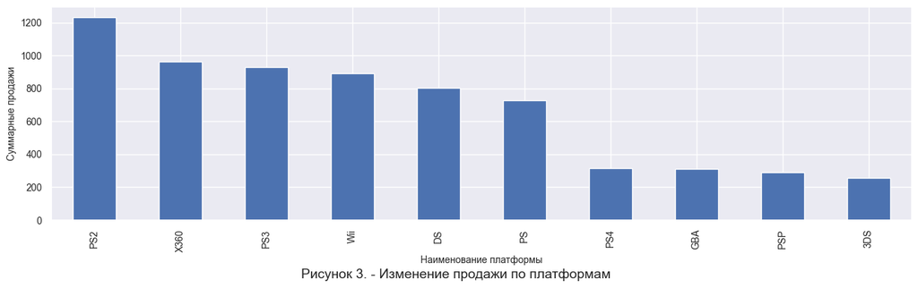

```
0     PS2
1    X360
2     PS3
3     Wii
4      DS
5      PS
Name: platform, dtype: object
```

```python
sales_group = games.groupby('platform')['total_sales'].sum().sort_values(ascending=False)[:10]
sales_group.plot(kind='bar',figsize=(16,4))

plt.xlabel("Наименование платформы", fontsize=10)
plt.ylabel('Суммарные продажи', fontsize=10)
plt.xticks(fontsize=10)
plt.yticks(fontsize=10)
plt.figtext(0.35, -0.1, "Рисунок 3. - Изменение продажи по платформам", fontsize=14)
plt.show()

sales_group = sales_group.reset_index(drop=False)
sales_group
favor_platform = sales_group['platform'].head(6)
favor_platform
```

**ОТЛИЧНО! 👍**

**games.groupby('platform')['total_sales'].sum().sort_values(ascending=False)[:10]** - совсем немногие студенты делают выборку топ-Х платформ так как это делаешь ты, в коде. Процентов 80 формируют подобный list вручную. Молодец!

```python
#favor_platform = ['PS2', 'X360', 'PS3', 'Wii', 'DS', 'PS']
```

**Вывод:** Распределение показывает, что лидерами рынка продаж являются платформы: PS2, X360, PS3, Wii, DS, PS. Максимальные суммарные продажи принесла платформа **PS2**

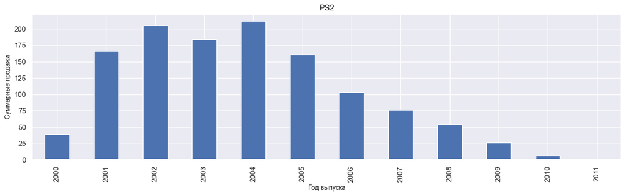

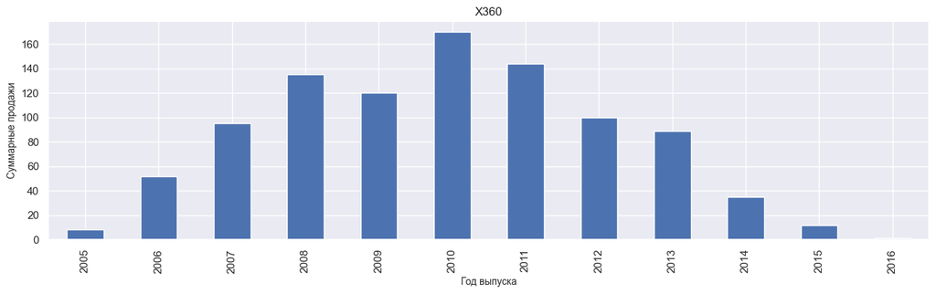

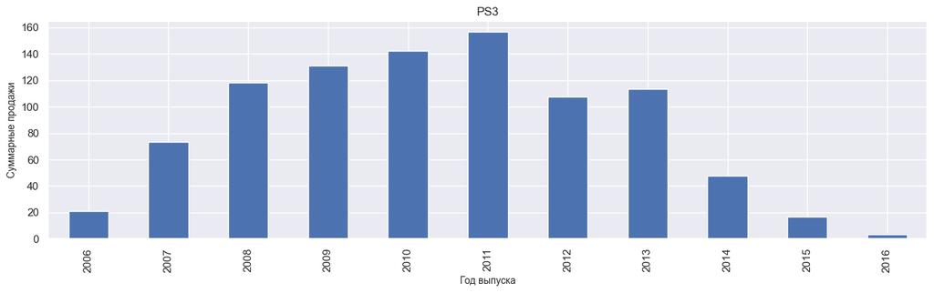

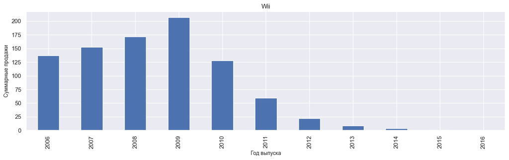

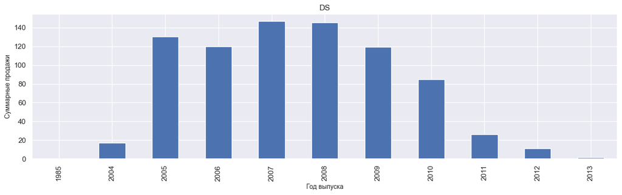

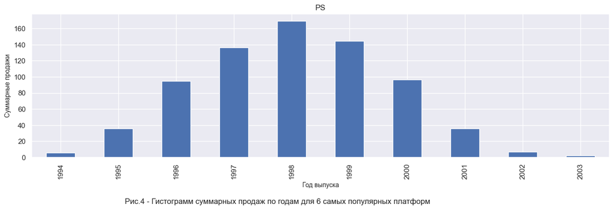

```python
# рассмотрим жизненный цикл на примере патформ с наибольшими суммарными продажами

for i in range(len(favor_platform)):

    platforms = favor_platform[i]
    games.query('platform==@platforms').groupby('year_of_release')['total_sales'].sum().plot(
    kind='bar', grid=True,figsize=(16,4))
    plt.title(platforms) # присвоение заголовка гистограмме
    plt.xlabel("Год выпуска", fontsize=10)
    plt.ylabel('Суммарные продажи', fontsize=10)

    if i == len(favor_platform)-1 :
        plt.figtext(0.25, -0.14, "Рис.4 - Гистограмм суммарных продаж по годам для 6 самых популярных платформ")

    plt.show()
```

**Комментарий 👉**

1. Здесь конечно, по сути, надо бы список с топ-6 платформами автоматизировано формировать. Ты только представь, что тебе нужно не 6, а скажем 150 значений указать, или в коде, в разных местах иметь разный топ-Х. Сделаешь?
2. И строить графики желательно в цикле.

**КОММЕНТАРИЙ СТУДЕНТА**

замечание учтено - графики построены в цикле.

3. Выявим за какой характерный срок появляются новые и исчезают старые платформы?

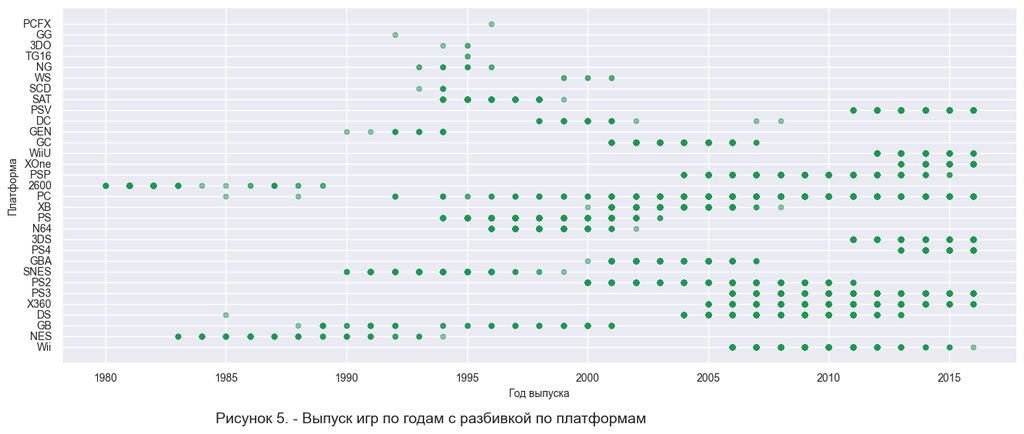

```python
# посмотрим на распределение выпускаемых игр по годам с разбивкой по платформам по средством диаграммы рассеяния

color = np.array([.1, .6, .3])
games.plot(x='year_of_release', y='platform', kind='scatter',\
figsize=(16, 6), grid=True, alpha=0.5,c=color.reshape(1,-1))

plt.xlabel("Год выпуска", fontsize=10)
plt.ylabel('Платформа', fontsize=10)
plt.xticks(fontsize=10)
plt.yticks(fontsize=10)
plt.figtext(0.25, -0.02, "Рисунок 5. - Выпуск игр по годам с разбивкой по платформам", fontsize=14)
plt.show()
```

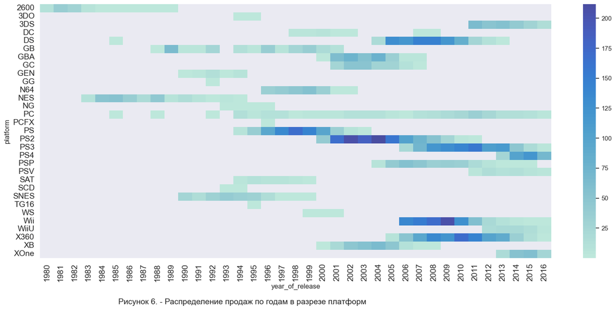

```python
# посмотрим на распределение выпускаемых игр по годам с разбивкой по платформам по средством тепловой карты

sns.set(rc={'figure.figsize':(20,8)})
sns.heatmap(games.pivot_table(index='platform', columns='year_of_release',\
values='total_sales',aggfunc='sum'), center=350)

plt.xticks(fontsize=14)
plt.yticks(fontsize=14)
plt.figtext(0.22, -0.03, "Рисунок 6. - Распределение продаж по годам в разрезе платформ", fontsize=14)
```

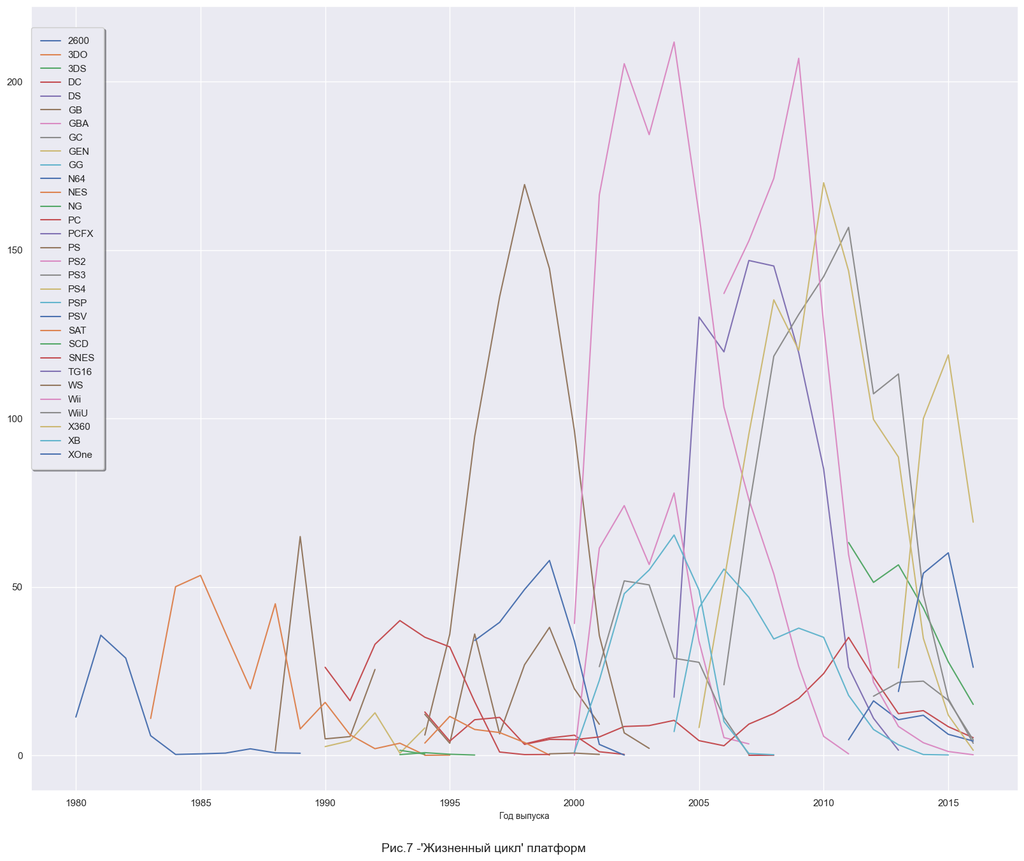

```python
# посмотрим на распределение выпускаемых игр по годам с разбивкой по платформам по средством линейного графика

games.pivot_table(index='year_of_release', columns='platform', values='total_sales',aggfunc='sum').plot(
    figsize=(20,16), grid=True)

plt.figtext(0.4, 0.05, "Рис.7 -'Жизненный цикл' платформ", fontsize=14)
plt.xlabel("Год выпуска", fontsize=10)
plt.legend(loc=(0, 0.41), frameon=True, ncol=1,fancybox=True, framealpha=1, shadow=True, borderpad=1)
plt.show()
```

**Комментарий 👉**

Код очень длинный (а PEP8 определяет длину строки в 79 символов) - попробуй длинные - переносить, а между строками использовать пустые строки. Ну и желательно код комментировать, хотя бы коротко (что делаешь и каков будет результат - так твоим коллегам будет проще за твоей мыслью следить). Этот комментарий может относиться к нескольким ячейкам этой «тетрадки».

Хороший разработчик форматирует и комментирует свой код, тогда другие разработчики быстрее разберутся в программе. Это важно, ведь код чаще читают, чем пишут: напишет один, а прочтут — сотни или тысячи (если код хороший). «Пишите код так, как будто сопровождать его будет склонный к насилию психопат, который знает, где вы живете.» ©1991, John F. Woods, разработчик

Давай обсудим стиль кодирования (программирования)? Смотри что сейчас происходит в этой ячейке (**возможно не всё применимо к твоему коду здесь, но я попытался вспомнить все часто встречающиеся недочёты**), что "режет" глаз и что можно сделать по-другому, чуть лучше:

1. Комментарии к строке кода: они должны располагаться выше соответствующей строки кода (выше строки к которой относятся) и должны быть от этой строки отделены пустой строкой. Если же они расположены справа, то для того чтобы увидеть, что там написано приходится пользоваться скроллиногом. Надо добиться того, чтобы ячейку не приходилось прокручивать, т.к. это не добавляет удобства ни при отладке кода, ни для понимания что в этой ячейке "происходит". Как альтернатива – комментарий может размещаться выше, в Markdown-ячейке.
2. Бывает, что встречаются очень длинные строки кода, которые также уходят за правый край ячейки. Такие строки должны разбиваться разделителем (вот таким: \). Это best practice, требование PEP8, а именно: PEP8 определяет длину строки в 79 символов.
3. **В идеале**: одна ячейка - одна строка кода. Почему так? Да как минимум из соображения понятности: будучи выполненной, под этой ячейкой должен отображаться результат трансформации данных. Ты или твой коллега должны видеть, как поменялись данные после выполнения ячейки с кодом. Следующая ячейка - ещё строка кода и соответствующим output'ом. Будешь делать так - коллеги будут тебе благодарны за то, что легко будут следовать за твоей мыслью. И отладку это упрощает.

Ну и как противоположность - можно в одну ячейку "положить" результат 3-х последовательных groupby + ещё чего-нибудь. Разобраться с ходу "что происходит" будет очень трудно, придётся всё равно код разносить по ячейкам и смотреть последовательно что происходит. Но ведь логично это делать удобным способом сразу, ведь так?

4. Неиспользуемые, закомментированные строки выше вынеси в другую ячейку, отдельную, выше. Можешь для удобства своего прокомментировать (на память). И оставь там это код, так, чтобы он не смешивался с рабочим кодом.

**КОММЕНТАРИЙ СТУДЕНТА**

замечание учтено - внесены корректировки, буду стараться придерживаться правил оформления.

```python
# на примере патформ с наибольшими суммарными продажами выявим время жизни платформ

favor_platform = ['PS2', 'X360', 'PS3', 'Wii', 'DS', 'PS']
year_life=[]
for platforms in favor_platform:
    platforms_diff = games.query('platform==@platforms')['year_of_release'].max()-\
    games.query('platform==@platforms')['year_of_release'].min()
    year_life.append(platforms_diff)
    print(platforms, platforms_diff)

mean = int(round((sum(year_life) / len(year_life)),0))
print('Среднее время жизни платформы: ',mean, 'лет.')
```

```
PS2 11
X360 11
PS3 10
Wii 10
DS 28
PS 9
Среднее время жизни платформы:  13 лет.
```

При подсчете продолжительности жизни у платформы DS выявлено время существования 28 лет, согласно дынным wikipedia: консоль была выпущена в 2004 году в Канаде, США и Японии, таким образом попавшие в выборку ранее указанной даты игры являются артифактами.

```python
# рассмотрим игры, содержащиеся в датафрейме, выпущенные ранее 2004 года:
games.query('(platform=="DS") and (year_of_release < 2004)')
```

|  | name | platform | year_of_release | genre | na_sales | eu_sales | jp_sales | other_sales | critic_score | user_score | rating | total_sales |
| --- | --- | --- | --- | --- | --- | --- | --- | --- | --- | --- | --- | --- |
| 15704 | Strongest Tokyo University Shogi DS | DS | 1985 | Action | 0.0 | 0.0 | 0.02 | 0.0 | 150.0 | 150.0 |  | 0.02 |

Выявлена одна игра сроком выпуска 1985 - явно являющаяся артефактом, так как данная позиция содержала прописки в оценках критиков и пользователей и не несет ценной информации - удалим из дальнейшего анализа

```python
print('Количество строк до удаления',games.shape[0])
```

```
Количество строк до удаления 16443
```

```python
games = games.drop(games.index[15704],axis=0).reset_index(drop=True)
```

```python
print('Количество строк до удаления',games.shape[0])
```

```
Количество строк до удаления 16442
```

```python
# повторно произведем расчет средней продолжительности жизни платформ

favor_platform = ['PS2', 'X360', 'PS3', 'Wii', 'DS', 'PS']
year_life=[]
for platforms in favor_platform:
    platforms_diff = games.query('platform==@platforms')['year_of_release'].max()-\
    games.query('platform==@platforms')['year_of_release'].min()
    year_life.append(platforms_diff)
    print(platforms, platforms_diff)

mean = int(round((sum(year_life) / len(year_life)),0))
print('Среднее время жизни платформы: ',mean, 'лет.')
```

```
PS2 11
X360 11
PS3 10
Wii 10
DS 9
PS 9
Среднее время жизни платформы:  10 лет.
```

**Комментарий 👉**

**ds=games.query('platform=="DS"and year_of_release!=2045')** - откуда здесь 2045 год взялся?

**КОММЕНТАРИЙ СТУДЕНТА**

датафрейм не содержит данные по 2045 году - данный кусок кода является опечаткой и никак не влияет на результат выполнения

**Комментарий 👉**

Почему по твоим данным платформа DS уже 28 лет на рынке? Посмотри пожалуйста в Интернете когда она "появилась на свет"?

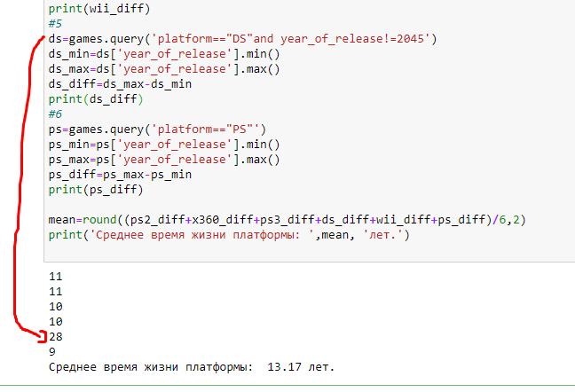

**Вывод:** платформы с наибольшими суммарными продажами набрали свою популярность с начала 2000-х., а период от первых продаж до исчезнования в среднем занял 10 лет.

**Комментарий 👉**

**период от первых продаж до исчезнования в среднем занял 13 лет.** - цифра должна быть меньше.

**КОММЕНТАРИЙ СТУДЕНТА**

произведено подробное рассмотрение платформа DS - выявлен и удален артефакт. Повторно произведен расчет среднего периода жизни платформ, который составил 10 лет.

4. На осовании данных за соответствующий актуальный период определим какие платформы лидируют по продажам, растут или падают?

```python
# посмотрим на актуальные платформы 2016
games_2016=games[(games['year_of_release']==2016)&(games['total_sales']!=0)]
print('В 2016 существуют платформы:',games_2016['platform'].unique())
```

```
В 2016 существуют платформы: ['PS4' '3DS' 'XOne' 'WiiU' 'PS3' 'PC' 'X360' 'PSV' 'Wii']
```

Посмотрим выбросы с помощью Диаграмма рассеяния и Диаграммы размаха

```python
games.sample(3)
```

|  | name | platform | year_of_release | genre | na_sales | eu_sales | jp_sales | other_sales | critic_score | user_score | rating | total_sales |
| --- | --- | --- | --- | --- | --- | --- | --- | --- | --- | --- | --- | --- |
| 15666 | Exhibition Volume 6 | XB | 2004 | Misc | 0.01 | 0.00 | 0.0 | 0.0 | 150.0 | 150.0 |  | 0.01 |
| 12384 | Santa Claus Is Comin' to Town! | Wii | 2011 | Puzzle | 0.06 | 0.00 | 0.0 | 0.0 | 150.0 | 150.0 | E | 0.06 |
| 9894 | Phantom Dust | XB | 2004 | Action | 0.08 | 0.02 | 0.0 | 0.0 | 81.0 | 8.5 | T | 0.10 |

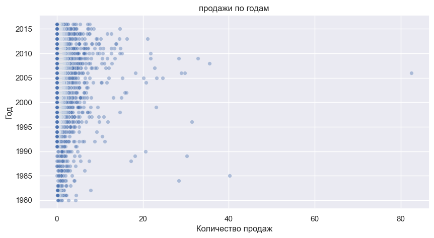

```python
plt.figure(figsize=(10, 5))
sns.scatterplot(data = games, x='total_sales', y='year_of_release', alpha=0.4, s=30)
plt.title('продажи по годам')
plt.xlabel('Количество продаж')
plt.ylabel('Год');
```

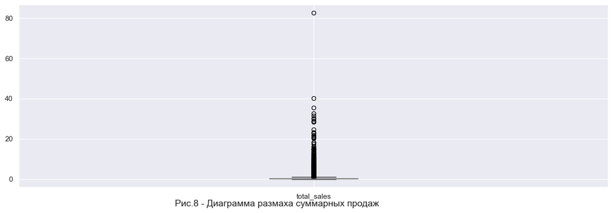

```python
# выявим выбросы:
games.boxplot(column=['total_sales'], figsize=(16,5), grid=True)
plt.figtext(0.33, 0.03, "Рис.8 - Диаграмма размаха суммарных продаж ", fontsize=14)
plt.show()
```

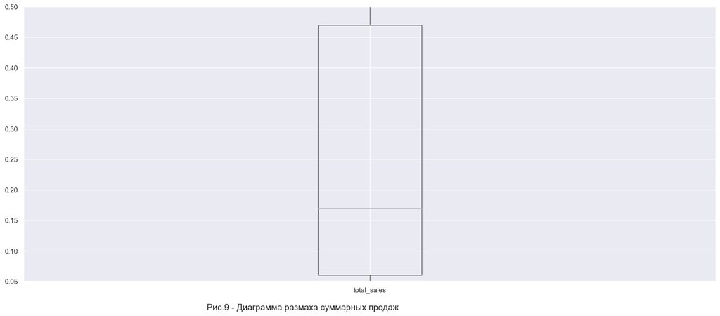

```python
# и диаграмму размаха без выбросов:
plt.ylim(0.05, 0.5)
games.boxplot(column=['total_sales'], figsize=(16,5), grid=True)
plt.figtext(0.33, 0.03, "Рис.9 - Диаграмма размаха суммарных продаж ", fontsize=14)
plt.show()
```

Из данных графиков видно, что основное количество продаж по платформам от 50 до 500 тысяч экземпляров. Другие значения можно считать выбросами.

**Комментарий 👉**

График не говорящий, на нем ничего из-за выбросов не видно.

```python
# за выбросы примем значения продаж выше 40, отбрасываем выбросы
games_filter = games[games['total_sales'] < 40]
# по гистограмме (рис.2) выбираем актуальный период с 2001 по 2015
games_filter = games[(games['year_of_release'] > 2000) & (games['year_of_release'] <= 2016)]
```

**Необходимо исправить ❌**

**games_filter=games[(games['year_of_release'] > 2000) & (games['year_of_release'] < 2016)]** - Нет, здесь ты берешь для анализа слишком большой интервал.

Для стремительно развивающейся игровой индустрии период > 3-4 лет — очень много. Внутри выбранного тобой периода произошли резкие изменения, например, произошла замена одного поколения консолей следующим (PS -> PS2 -> PS3 -> PS4). Некоторые платформы совсем исчезли (например, платформа DS не имеет новых релизов игр с 2013 года, PS2 с 2011 года, PSP с 2015 года). Как думаешь - помогут нам эти платформы построить прогноз на 2017 год или всё же лучше уменьшить интервал для анализа?

Для целей прогнозирования продаж на следующий год даже в традиционных бизнесах редко берут данные более чем за 2-3 года. А в такой динамично меняющейся индустрии, как компьютерные игры и вовсе не стоит брать слишком большой временной интервал - иначе обязательно захватишь уже отжившие тренды. В нашем случае думаю, что 3 года: 2014, 2015 и неполный 2016 - ОК.

Когда изменишь "горизонт" анализа и перезапустишь код в этой "тетрадке" - посмотри, как поменяется этот и все последующие выводы.

**Необходимо исправить ❌**

То, что мы исключаем из актуального периода данные за 2016 год - серьёзная ошибка. Не брать данные продаж по платформам за 2016 год только потому, что он "не полный" - неправильно. В данных 2016 года находятся самые актуальные, текущего периода тренды. Они очень пригодятся нам, чтобы сделать качественный прогноз на 2017 год.

**ОТЛИЧНО! 👍**

Очень хорошо, что результат запроса/’среза’ ты присваиваешь новому датафрейму. Таким образом оригинальный датафрейм ты оставляешь нетронутым, не перезаписываешь (вдруг нам опять понадобятся данные из него чуть ниже). Это верное решение. Best practice. Молодец!

```python
print('В выбранном актуальном периоде существуют платформы:\n',*games_filter['platform'].unique().astype('str'))
```

```
В выбранном актуальном периоде существуют платформы:
 Wii DS X360 PS3 PS2 GBA PS4 3DS XB PC PSP XOne WiiU GC PS PSV GB N64 DC WS
```

Таким образом, при анализе данных с отсечкой за 2016 года, мы не пропускаем ни одну платформу ( в 2016 существуют платформы: PS4, 3DS, XOne, WiiU, PS3, PC, X360, PSV, Wii).

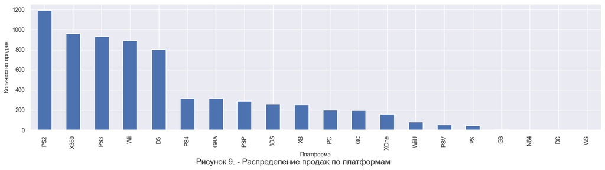

```python
games_filter.groupby('platform').total_sales.sum().sort_values(ascending=False).plot(kind='bar',figsize=(18,4))
plt.xlabel("Платформа", fontsize=10)
plt.ylabel('Количество продаж', fontsize=10)
plt.xticks(fontsize=10)
plt.yticks(fontsize=10)
plt.figtext(0.35, -0.1, "Рисунок 9. - Распределение продаж по платформам", fontsize=14)
plt.show()
```

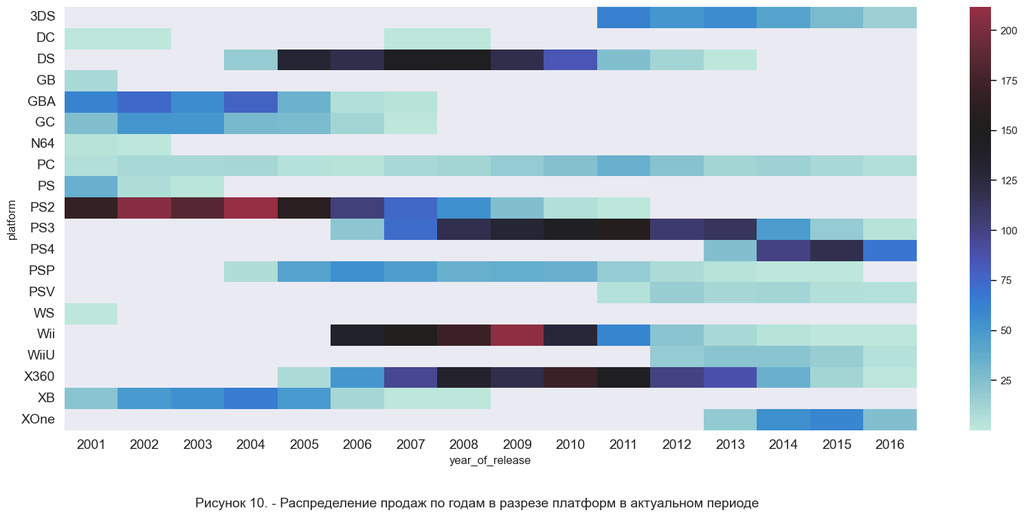

```python
sns.set(rc={'figure.figsize':(20,8)})
sns.heatmap(games_filter.pivot_table(index='platform', columns='year_of_release', values='total_sales',aggfunc='sum'), center=150)
plt.xticks(fontsize=14)
plt.yticks(fontsize=14)
plt.figtext(0.22, -0.03, "Рисунок 10. - Распределение продаж по годам в разрезе платформ в актуальном периоде", fontsize=14)
```

Визуализация показала, что в актуальном периоде лидирующие позиции по продажам по-преждему принадлежит платформе PS2, за ней следуют платформы X360, PS3, Wii, DS. Продажи по вышеназванным платформам падают - то есть компании достигли своего "пика" дохода/спроса и находятся в стадиях зрелости, либо упадка.

5. Выберем несколько потенциально прибыльных платформ.

Исключим из анализа ранее рассмотренные платформы (PS2, X360, PS3, Wii, DS, PS):

```python
games_filter_prognoz = games_filter[(games_filter['platform']!='PS2')&(games_filter['platform']!='X360')&(games_filter['platform']!='PS3')&(games_filter['platform']!='Wii')&(games_filter['platform']!='DS')&(games_filter['platform']!='PS')]
platform_prognoz = games_filter_prognoz['platform'].unique()
print('Визуализируем распределения для платформ: \n', *platform_prognoz)
```

```
Визуализируем распределения для платформ:
 GBA PS4 3DS XB PC PSP XOne WiiU GC PSV GB N64 DC WS
```

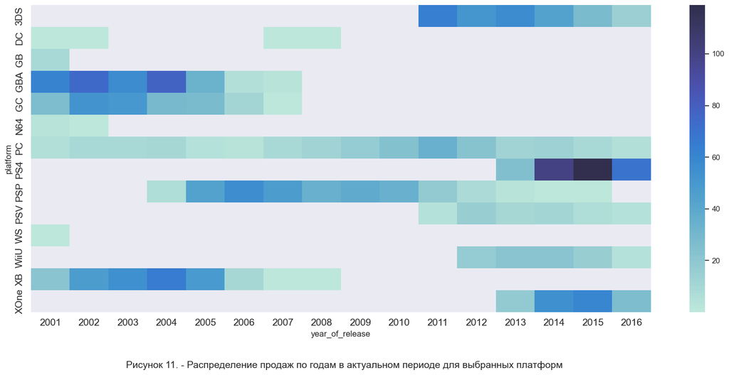

```python
sns.set(rc={'figure.figsize':(20,8)})
sns.heatmap(games_filter_prognoz.pivot_table(index='platform', columns='year_of_release', values='total_sales',aggfunc='sum'), center=150)
plt.xticks(fontsize=14)
plt.yticks(fontsize=14)
plt.figtext(0.22, -0.03, "Рисунок 11. - Распределение продаж по годам в актуальном периоде для выбранных платформ", fontsize=14)
```